# Fifty States Project

7/10/2022

## Data Source and Procedures

### Open Source Software & Publicly Available Data

- GSOM (Global Summary of Monthly Data)
- Analysis and Graphics R/Rstudio
- Selected Station with longest records and fewest missing data
- Select month had strongest trend
- Evaluate Monthly Temp. Max and Min for trends

## Weather Station Selected

- Station ID GUAM INTERNATIONAL AIRPORT, US (ID: GHCND:GQW00041415)
- Records begin: 1957
- Records end: 2022
- Not necessarily representative of the state or similar to other stations in Guam!

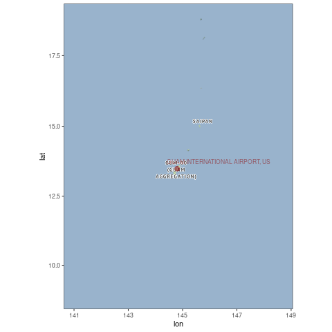

## Months with Largest Changes

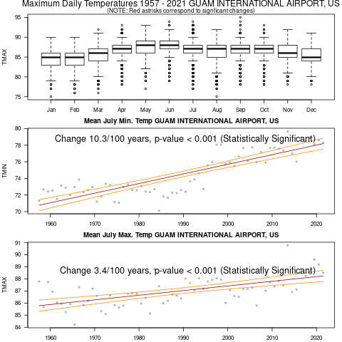

## Record Temperatures

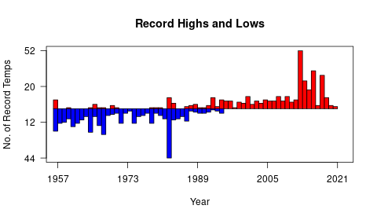

## Max. Temperature Anomaly Trend

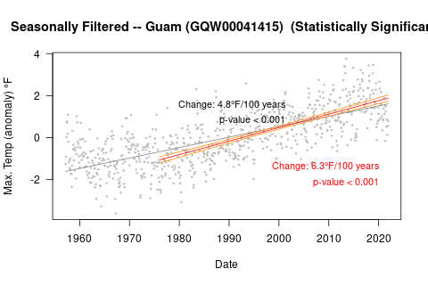

## Impacts

- In the coming decades, changes in the earth’s atmosphere are likely to alter several aspects of life in Guam.
- The air and ocean are warming, sea level is rising, and the ocean is becoming more acidic.
- These changes are likely to damage or destroy much of Guam’s coral reef ecosystems, increase damages from flooding and typhoons, reduce the availability of fresh water during the dry season, and make air temperatures uncomfortably hot more often than they are today.

[EPA Snapshot](https://19january2017snapshot.epa.gov/sites/production/files/2016-09/documents/climate-change-gu.pdf)

## Impacts

- East-West Center has a most more detailed discussion on the impacts on Guam.
- Average Temperatures have increase.
- Hot days have increased.
- Cold days have decreased.
- Extreme rain fall events increased.

[Climate Change in Guam: Indicators and Considerations for Key Sectors by Zena Grecni, Wendy Miles, Romina King, Abby Frazier, and Victoria Keener November 9, 2020](https://www.eastwestcenter.org/system/tdf/private/climate-change-in-guam-pirca-2020-low-res.pdf?file=1&type=node&id=38766)

## State Adaptation / Mitigation Plans

- Unable to find a comprehensive adapation / mitigation plan for Guam.

[Source: Georgetown Climate Center] (https://www.georgetownclimate.org/adaptation/state-information/guam/overview.html)

## Next Steps

- Put ideas in comments how what other can do to support state efforts
- Be kind: Responding to climate change includes a complex array of ethical issues.
- “Be curious”, Ted Lasso.